# Whole Game

Exercise

CCS

Exercise

Data Science

Author

Felix Dietrich

Published

December 6, 2022

# Instructions

- Please finish the complete exercise (no. 1-4)
- If you get stuck at some point, please describe the problem as detailed as possible
- If there are multiple options (e.g., “a” or “b”), you can chose one option

You can either use a local installation of R and the required packages or the Docker image for this class, which now includes all packages that we have used so far.

```bash
docker run \
  --name=rproject \
  -d \
  -e USER=rstudio \
  -e ROOT=true \
  -e PASSWORD=ccs \
  -p 80:8787 \
  -v $(pwd):/home/rstudio/host \
  --rm \
  felixdidi/22-2-ccs
```

Also, to use RSelenium, we need to start a Selenium Container on our local machine.

```bash
docker run --name=selenium_container -d -p 4445:4444 --rm selenium/standalone-firefox:2.53.1
```

The easiest way to run both together is by using docker-comose and including the following `compose.yml`:

```yaml
services:
  rstudio:
    image: felixdidi/22-2-ccs
    ports:
      - "80:8787"
    links:
      - selenium:selenium
    volumes:
      - .:/home/rstudio/host
    env_file:
    - .env
  selenium:
    image: selenium/standalone-firefox:2.53.1
    ports:
      - "4445:4444"
```

# Setup

We used R (Version 4.2.1; R Core Team, 2022) and the R-packages *oolong* (Version 0.4.1; Chan & Sältzer, 2020), *papaja* (Version 0.1.1; Aust & Barth, 2022), *quanteda* (Version 3.2.3; Benoit et al., 2018), *RSelenium* (Version 1.7.9; Harrison, 2022), *rvest* (Version 1.0.2; Wickham, 2021), *tidytext* (Version 0.3.4; Silge & Robinson, 2016), *tidyverse* (Version 1.3.2; Wickham et al., 2019), *udpipe* (Version 0.8.9; Wijffels, 2022), and *webdriver* (Version 1.0.6; Hidayat et al., 2021) for our analyses and to compile this report.

# 1 Get text data

Gather some text data about the UN Conference on Climate Change (COP27).

## (a) Tweets

**Instruction:** Gather as many tweets as possible that use the hashtag `#COP27` in a timeframe around the conference date.

**Solution:** If you use the Docker image, you need to install the `rtweet` package (I forgot to include it in the Docker image 🙈). Also, you need to import your authentication because this does not work interactively in RStudio Server. If you run a local installation of R and RStudio, you should be able to authenticate when running a function from the package for the first time. To import authentication, authenticate locally (as described in the package documentation) and then save your access token with `rtweet::auth_save("rtweet_auth")`. You can then import and authenticate as documented below:

```r
# this code chunk is not evaluated when rendering
# instead, we load the scraped tweets below

# install the package
install.packages("rtweet", dependencies = TRUE)
# load it
library(rtweet)

# authenticate
auth <- readRDS("rtweet_auth.rds")
auth_as(auth)

# get tweets
tweets <-
  rtweet::search_tweets(
    q = "#COP27", # query
    # n = Inf, # download as many tweets as possible
    # might be resticted by rate limits, which we can account for
    retryonratelimit = TRUE, # account for rate limits
    n = 500, # get 500 tweets for demo
    include_rts = FALSE # exlude retweets
    )

# save tweets
save(tweets, file = "tweets")
```

```r
# tweets are loaded with this chunk from saved data
load("tweets")

tweets
```

```
# A tibble: 485 × 43
   created_at               id id_str       full_…¹ trunc…² displ…³ entities
   <dttm>                <dbl> <chr>        <chr>   <lgl>     <dbl> <list>
 1 2022-12-05 12:42:27 1.60e18 15997460183… "This … FALSE       266 <named list>
 2 2022-12-05 12:19:01 1.60e18 15997401201… "The …  FALSE       281 <named list>
 3 2022-12-05 11:54:12 1.60e18 15997338773… "🤔 So… FALSE       277 <named list>
 4 2022-12-06 18:26:50 1.60e18 16001950750… "Been … FALSE       273 <named list>
 5 2022-12-06 18:25:00 1.60e18 16001946117… "On #c… FALSE       291 <named list>
 6 2022-12-06 18:23:50 1.60e18 16001943195… "@Nick… FALSE       289 <named list>
 7 2022-12-06 18:23:49 1.60e18 16001943137… "Amazi… FALSE       159 <named list>
 8 2022-12-06 18:21:04 1.60e18 16001936244… "COP27… FALSE       171 <named list>
 9 2022-12-06 18:20:05 1.60e18 16001933760… "AMERI… FALSE       280 <named list>
10 2022-12-06 18:20:00 1.60e18 16001933531… "Globa… FALSE       173 <named list>
# … with 475 more rows, 36 more variables: metadata <list>, source <chr>,
#   in_reply_to_status_id <dbl>, in_reply_to_status_id_str <chr>,
#   in_reply_to_user_id <dbl>, in_reply_to_user_id_str <chr>,
#   in_reply_to_screen_name <chr>, geo <list>, coordinates <list>,
#   place <list>, contributors <lgl>, is_quote_status <lgl>,
#   retweet_count <int>, favorite_count <int>, favorited <lgl>,
#   retweeted <lgl>, possibly_sensitive <lgl>, lang <chr>, …
```

## (b) News Articles

**Instruction:** Get news articles which have been published in a timeframe around the conference date which refer to the Climate Conference. News articles might be accessible through APIs, Web Scraping, or data bases such as GDELT.

**Solution:** For this example, we compare tagesschau and Frankfurter Allgemeine Zeitung news articles so that we can make use of the archive scrapers from the [fodira project](https://github.com/chainsawriot/fodira/tree/master/archive_scrapers). We scrape news articles from both websites for the timeframe of the conference, which was 6 November until 20 November 2022.

### tagesschau

First, let’s get the links for all tagesschau articles. To do this, we use the scraper functions from fodira.

```r
# define the scraper functions
tagesschau_getlink <- function(html){

  rvest::read_html(html) %>%
    rvest::html_elements(xpath = "//span[contains(@class, 'teaser-xs__headline')]") %>%
    rvest::html_text(., trim = TRUE) -> item_title

  rvest::read_html(html) %>%
    rvest::html_elements(xpath = "//a[contains(@class, 'teaser-xs__link')]") %>%
    rvest::html_attr("href")  -> item_link

  rvest::read_html(html) %>%
    rvest::html_elements(xpath = "//span[contains(@class, 'teaser-xs__date')]") %>%
    rvest::html_text(., trim = TRUE) %>%
    as.Date(., tryFormat = c("%d.%m.%Y - %H:%M Uhr")) -> item_pubdate

  df <- data.frame(item_title, item_link, item_pubdate)
  return(df)
}

tagesschau_getlink_url <- function(url){
  pjs_session$go(url)
  Sys.sleep(4)
  print(url)
  return(tagesschau_getlink(pjs_session$getSource()))
}


tagesschau_go_thr_archive <- function(startdate, enddate){
  V1<-seq(as.Date(startdate), as.Date(enddate), by="days")

  V1 %>% as.character() %>%
    paste0("https://www.tagesschau.de/archiv/?datum=", .) %>%
    purrr::map_df(~tagesschau_getlink_url(.)) -> valid_links

  return(valid_links)
}
```

Next, let’s do the scraping:

```r
# this code chunk is not evaluated when rendering because we load the scraped links below
# install and run phantomjs
webdriver::install_phantomjs()
pjs_instance <- run_phantomjs()
pjs_session <- Session$new(port = pjs_instance$port)

# get article links
tagesschau_links <- tagesschau_go_thr_archive("2022-11-06", "2022-11-20")

# rename some variables
tagesschau_links <-
  tagesschau_links %>%
  dplyr::rename(title = item_title, link = item_link, pubdate = item_pubdate) %>%
  dplyr::mutate(pub = "Tagesschau", description = NA) %>%
  dplyr::select(pub, link, pubdate, title, description)

# save
save(tagesschau_links, file = "tagesschau_links")
```

```r
# load saved links
load("tagesschau_links")

tagesschau_links %>% as_tibble()
```

```
# A tibble: 680 × 5
   pub        link                                      pubdate    title descr…¹
   <chr>      <chr>                                     <date>     <chr> <lgl>
 1 Tagesschau https://www.tagesschau.de/inland/frankfu… 2022-11-06 Ober… NA
 2 Tagesschau https://www.tagesschau.de/inland/innenpo… 2022-11-06 83 M… NA
 3 Tagesschau https://www.tagesschau.de/newsticker/liv… 2022-11-06 ++ E… NA
 4 Tagesschau https://www.tagesschau.de/ausland/afrika… 2022-11-06 Flug… NA
 5 Tagesschau https://www.tagesschau.de/inland/merz-bu… 2022-11-06 Merz… NA
 6 Tagesschau https://www.tagesschau.de/ausland/iran-d… 2022-11-06 Erne… NA
 7 Tagesschau https://www.tagesschau.de/ausland/ukrain… 2022-11-06 Was … NA
 8 Tagesschau https://www.tagesschau.de/inland/ekd-syn… 2022-11-06 Unei… NA
 9 Tagesschau https://www.tagesschau.de/wirtschaft/unt… 2022-11-06 Ande… NA
10 Tagesschau https://www.tagesschau.de/inland/exil-ru… 2022-11-06 Gefl… NA
# … with 670 more rows, and abbreviated variable name ¹description
```

```r
# this code chunk is not evaluated when rendering because we load the scraped articles below

# create empty container for data
tagesschau_data <- tibble(url = NULL, text = NULL)

# set counter to 0
count <- 0

# loop over all links and scrape article text
for (url in tagesschau_links$link) {

  html_text <- read_html(url) %>%
    html_nodes(".textabsatz") %>%
    html_text2() %>%
    str_flatten()

  temp_df <- tibble(url = url, text = html_text)

  tagesschau_data <- bind_rows(tagesschau_data, temp_df)

  print(count)
  count <- count + 1
  print(url)
  Sys.sleep(2)
}

# combine with links
tagesschau_data <- left_join(tagesschau_data, tagesschau_links, by = c("url" = "link"))

# save
save(tagesschau_data, file = "tagesschau_data")
```

```r
load("tagesschau_data")

tagesschau_data
```

```
# A tibble: 680 × 6
   url                                      text  pub   pubdate    title descr…¹
   <chr>                                    <chr> <chr> <date>     <chr> <lgl>
 1 https://www.tagesschau.de/inland/frankf… "Der… Tage… 2022-11-06 Ober… NA
 2 https://www.tagesschau.de/inland/innenp… "Für… Tage… 2022-11-06 83 M… NA
 3 https://www.tagesschau.de/newsticker/li… "EU-… Tage… 2022-11-06 ++ E… NA
 4 https://www.tagesschau.de/ausland/afrik… "In … Tage… 2022-11-06 Flug… NA
 5 https://www.tagesschau.de/inland/merz-b… "Die… Tage… 2022-11-06 Merz… NA
 6 https://www.tagesschau.de/ausland/iran-… "Im … Tage… 2022-11-06 Erne… NA
 7 https://www.tagesschau.de/ausland/ukrai… "Die… Tage… 2022-11-06 Was … NA
 8 https://www.tagesschau.de/inland/ekd-sy… "Die… Tage… 2022-11-06 Unei… NA
 9 https://www.tagesschau.de/wirtschaft/un… "Übe… Tage… 2022-11-06 Ande… NA
10 https://www.tagesschau.de/inland/exil-r… "Aus… Tage… 2022-11-06 Gefl… NA
# … with 670 more rows, and abbreviated variable name ¹description
```

Let’s extract all articles that cover the climate conference:

```r
tagesschau_climate <-
  tagesschau_data %>%
  filter(str_detect(text, "Klimakonferenz"))
```

### FAZ

Now, let’s get all links from Frankfurter Allgemeine Zeitung for the defined timeframe. To do this, we need to use Selenium to run an interactive webbrowser which can circumvent the browser cookie popup window on this site. Again, let’s first define the functions according to the fodira project.

```r
# define the scraper functions
faz_get_links <- function(html){

  rvest::read_html(html) %>%
    rvest::html_elements(xpath = "//div[contains(@class, 'Teaser620')]//a//h2") %>%
    rvest::html_text(trim = TRUE) -> item_title

  rvest::read_html(html) %>%
    rvest::html_elements(xpath = "//div[contains(@class, 'Teaser620')]/a[1]") %>%
    rvest::html_attr("href") %>% paste0("https://www.faz.net",.)-> item_link

  rvest::read_html(html) %>%
    rvest::html_elements(xpath = "//span[contains(@class, 'ThemaAuszeichnung')]") %>%
    rvest::html_text(trim = TRUE) %>% stringr::str_extract("[0-9]+\\.[0-9]+\\.[0-9]+") %>%
    lubridate::dmy()-> item_pubdate

  df <- data.frame(item_title, item_link, item_pubdate)
  return(df)
}


faz_get_url <- function(url){
  remDr$navigate(url)
  print(remDr$getCurrentUrl())
  remDr$getPageSource()[[1]] %>% faz_get_links() -> df
  return(df)
}

faz_go_thr_archive <- function(startdate, enddate){

  seq(as.Date(startdate), as.Date(enddate), by="days") %>%
    format.Date(format="-%Y-%B-%d") -> V1

  V1 %>% paste0("https://www.faz.net/artikel-chronik/nachrichten", ., "/") %>%
    purrr::map_df(~faz_get_url(.)) -> df


  return(df)
}
```

Now, let’s do the scraping:

```r
# this code chunk is not evaluated when rendering because we load the scraped links below

# on your local machine, you can Selenium inside another Docker container,
# as described above (Instructions)

# open connection to the browser on the port which we set for the
# selinium Docker container in the compose file
remDr <- remoteDriver(
  remoteServerAddr = "selenium",
  port = 4444L,
  browserName = "firefox"
)

# open remote driver
remDr$open(silent = TRUE)

# get article links
faz_links <- faz_go_thr_archive("2022-11-06", "2022-11-20")

# rename some variables
faz_links <-
  faz_links %>%
  dplyr::rename(title = item_title, link = item_link, pubdate = item_pubdate) %>%
  dplyr::mutate(pub = "FAZ", description = NA) %>%
  dplyr::select(pub, link, pubdate, title, description)

# save
save(faz_links, file = "faz_links")
```

```r
# load saved links
load("faz_links")

faz_links %>% as_tibble()
```

```
# A tibble: 2,696 × 5
   pub   link                                           pubdate    title descr…¹
   <chr> <chr>                                          <date>     <chr> <lgl>
 1 FAZ   https://www.faz.net/aktuell/politik/inland/me… 2022-11-06 Merz… NA
 2 FAZ   https://www.faz.net/aktuell/sport-15175124.ht… 2022-11-06 Gute… NA
 3 FAZ   https://www.faz.net/aktuell/sport-15175124.ht… 2022-11-06 Darm… NA
 4 FAZ   https://www.faz.net/aktuell/sport-15175124.ht… 2022-11-06 Fran… NA
 5 FAZ   https://www.faz.net/aktuell/rhein-main/frankf… 2022-11-06 Der … NA
 6 FAZ   https://www.faz.net/aktuell/sport/freiburg-be… 2022-11-06 Ein … NA
 7 FAZ   https://www.faz.net/aktuell/politik/buergeren… 2022-11-06 Fran… NA
 8 FAZ   https://www.faz.net/aktuell/politik/peter-fel… 2022-11-06 Waru… NA
 9 FAZ   https://www.faz.net/aktuell/politik/inland/so… 2022-11-06 Baye… NA
10 FAZ   https://www.faz.net/aktuell/wirtschaft/lindne… 2022-11-06 Lind… NA
# … with 2,686 more rows, and abbreviated variable name ¹description
```

```r
# this code chunk is not evaluated when rendering because we load the scraped articles below

# create empty container for data
faz_data <- tibble(url = NULL, text = NULL)

# set counter to 0
count <- 0

# loop over all links and scrape article text
for (url in faz_links$link) {

  html_text <- read_html(url) %>%
    html_nodes(".atc-TextParagraph") %>%
    html_text2() %>%
    str_flatten()

  temp_df <- tibble(url = url, text = html_text)

  faz_data <- bind_rows(faz_data, temp_df)

  print(count)
  count <- count + 1
  print(url)
  Sys.sleep(2)
}

# combine with links
faz_data <- left_join(faz_data, faz_links, by = c("url" = "link"))

# save
save(faz_data, file = "faz_data")
```

```r
load("faz_data")

faz_data
```

```
# A tibble: 2,694 × 6
   url                                      text  pub   pubdate    title descr…¹
   <chr>                                    <chr> <chr> <date>     <chr> <lgl>
 1 https://www.faz.net/aktuell/politik/inl… "CDU… FAZ   2022-11-06 Merz… NA
 2 https://www.faz.net/aktuell/sport-15175… ""    FAZ   2022-11-06 Gute… NA
 3 https://www.faz.net/aktuell/sport-15175… ""    FAZ   2022-11-06 Darm… NA
 4 https://www.faz.net/aktuell/sport-15175… ""    FAZ   2022-11-06 Fran… NA
 5 https://www.faz.net/aktuell/rhein-main/… "11.… FAZ   2022-11-06 Der … NA
 6 https://www.faz.net/aktuell/sport/freib… "Der… FAZ   2022-11-06 Ein … NA
 7 https://www.faz.net/aktuell/politik/bue… "Der… FAZ   2022-11-06 Fran… NA
 8 https://www.faz.net/aktuell/politik/pet… "Das… FAZ   2022-11-06 Waru… NA
 9 https://www.faz.net/aktuell/politik/inl… "Die… FAZ   2022-11-06 Baye… NA
10 https://www.faz.net/aktuell/wirtschaft/… "Fin… FAZ   2022-11-06 Lind… NA
# … with 2,684 more rows, and abbreviated variable name ¹description
```

Let’s extract all articles that cover the climate conference:

```r
faz_climate <-
  faz_data %>%
  filter(str_detect(text, "Klimakonferenz"))
```

# 2 Pre-Processing

**Instruction:** For some approaches (e.g., when using embeddings), simple pre-processing might be sufficient (or even advised). Decide how much pre-processing is suitable for your task and implement this below. You may chose a tidy or DFM based approach.

**Solution:** Here, I will use a tidytext approach (using the news articles scraped above). First, let’s combine tagesschau and FAZ data that cover the COP27:

```r
docs <- bind_rows(tagesschau_climate, faz_climate)

# clean
clean_docs <-
  docs %>%
    # clean punctuation
    mutate(clean_text = str_replace_all(text, "[:punct:]", "")) %>%
    # clean symbols
    mutate(clean_text = str_replace_all(clean_text, "[:symbol:]", "")) %>%
    # clean numbers
    mutate(clean_text = str_replace_all(clean_text, "[:digit:]", "")) %>%
    #clean hashtags
    mutate(clean_text = str_replace_all(clean_text, "#\\w+", "")) %>%
    # clean unnecessary white spaces
    mutate(clean_text = str_squish(clean_text)) %>%
    # relocate
    relocate(clean_text, .after = text) %>%
    # detect language
    mutate(cld2_lang = cld2::detect_language(clean_text)) %>%
    # and filter out only german texts
    filter(cld2_lang == "de") %>%
    # add doc id
    rowid_to_column(var = "doc_id")
```

Now, let’s lemmatize:

```r
# this code chunk is not evaluated when rendering
# instead, we load the lemmas below to increase rendering speed

# download language model
# ud_model_de <- udpipe_download_model(language = "german")

# load language model
ud_model_de <- udpipe_load_model("german-gsd-ud-2.5-191206.udpipe")

# lemmatize
lemmas <- udpipe(clean_docs$text,
                 object = ud_model_de,
                 parallel.cores = 8)

save(lemmas, file = "lemmas")
```

```r
load("lemmas")

# combine lemmas with article information
lemmas <- lemmas %>% mutate(doc_id = as.numeric(doc_id))
lemmas <- left_join(x = lemmas, y = clean_docs)

# summarise on document level
d <-
  lemmas %>%
  group_by(doc_id) %>%
  summarise(lemmatized_text = paste(lemma, collapse = " "),
            across(names(clean_docs)[-1])) %>%
  distinct() %>%
  relocate(lemmatized_text, .after = clean_text) %>%
  ungroup()

# unnest tokens and remove stopwords
tokens <- d %>%
  unnest_tokens(word, lemmatized_text, token = "words", to_lower = TRUE) %>%
  anti_join(get_stopwords(language = "de", source="stopwords-iso")) %>%
  filter(!str_detect(word, "NA")) %>% # remove "NA" resulting from lemmatization
  add_count(word) %>%
  filter(n > 20) # remove very infrequent terms

tokens
```

```
# A tibble: 10,249 × 11
   doc_id url   text  clean…¹ pub   pubdate    title descr…² cld2_…³ word      n
    <dbl> <chr> <chr> <chr>   <chr> <date>     <chr> <lgl>   <chr>   <chr> <int>
 1      1 http… "Die… Die We… Tage… 2022-11-06 Schm… NA      de      entw…    42
 2      1 http… "Die… Die We… Tage… 2022-11-06 Schm… NA      de      geben   157
 3      1 http… "Die… Die We… Tage… 2022-11-06 Schm… NA      de      erwä…    23
 4      1 http… "Die… Die We… Tage… 2022-11-06 Schm… NA      de      erde…    42
 5      1 http… "Die… Die We… Tage… 2022-11-06 Schm… NA      de      neu     106
 6      1 http… "Die… Die We… Tage… 2022-11-06 Schm… NA      de      zufo…    48
 7      1 http… "Die… Die We… Tage… 2022-11-06 Schm… NA      de      jed      37
 8      1 http… "Die… Die We… Tage… 2022-11-06 Schm… NA      de      verg…    53
 9      1 http… "Die… Die We… Tage… 2022-11-06 Schm… NA      de      begi…    29
10      1 http… "Die… Die We… Tage… 2022-11-06 Schm… NA      de      heiß…    47
# … with 10,239 more rows, and abbreviated variable names ¹clean_text,
#   ²description, ³cld2_lang
```

# 3 Analyzing

Follow one approach to analyzing texts that we have discussed in class.

## (a) Dictionary Analysis

**Instruction:** Conduct a dictionary based analysis of your texts (e.g., sentiment).

**Solution:** For this example, we use the tokens from the news articles in a tidy text approach (which we created above) and implement a German sentiment dictionary.

```r
# read in a German sentiment dictionary
load("Rauh_SentDictionaryGerman.Rdata")

sent_dictionary <-
  sent.dictionary %>%
  as_tibble() %>%
  mutate(
    # convert score to numeric variable
    sentiment = as.numeric(sentiment),
    # clean features (remove white space)
    feature = str_trim(feature)
    )

# add scores
scored <-
  left_join(tokens, sent_dictionary, by = c("word" = "feature")) %>% # join with scores
  mutate(value = if_else(is.na(sentiment), 0, sentiment)) %>% # missing words to 0
  group_by(doc_id) %>%
  summarise(sentiment = mean(value), .groups = "drop") %>%  # average score per text
  left_join(d) # join data back in

scored
```

```
# A tibble: 84 × 11
   doc_id sentiment url     text  clean…¹ lemma…² pub   pubdate    title descr…³
    <dbl>     <dbl> <chr>   <chr> <chr>   <chr>   <chr> <date>     <chr> <lgl>
 1      1   0.192   https:… "Die… Die We… "der W… Tage… 2022-11-06 "Sch… NA
 2      2   0.0965  https:… "In … In Ägy… "in Äg… Tage… 2022-11-06 "\"E… NA
 3      3   0.138   https:… "Dür… Dürre … "Dürr … Tage… 2022-11-06 "Kön… NA
 4      4   0.0537  https:… "Mit… Mit Bl… "mit B… Tage… 2022-11-06 "\"M… NA
 5      5   0.0847  https:… "Wie… Wie ge… "wie g… Tage… 2022-11-06 "Gro… NA
 6      6   0.0667  https:… "13 … Tage g… "13 Ta… Tage… 2022-11-06 "Wie… NA
 7      7  -0.00196 https:… "Der… Der uk… "der u… Tage… 2022-11-07 "++ … NA
 8      8   0.0769  https:… "Die… Die CO… "der C… Tage… 2022-11-07 "Die… NA
 9      9   0.0656  https:… "Bun… Bundes… "Bunde… Tage… 2022-11-07 "Aus… NA
10     10   0.0709  https:… "UN-… UNGene… "UN - … Tage… 2022-11-07 "\"W… NA
# … with 74 more rows, 1 more variable: cld2_lang <chr>, and abbreviated
#   variable names ¹clean_text, ²lemmatized_text, ³description
```

## (b) Topic Modeling

**Instruction:** Calculate a Structural Topic Model. Consider adding suitable covariates and identifying *k* through a data driven approach.

**Solution:** For this example, we use the tokens from the news articles in a tidy text approach (which we created above). The stm package, however, requires input as a quanteda corpus or sparse matrix. So, let’s first convert our tidy tokens into a sparse matrix.

```r
# sparse matrix
sparse_docs <- tokens %>%
  count(doc_id, word) %>%
  cast_sparse(doc_id, word, n)

sparse_docs[1:10, ]
```

```
10 x 217 sparse Matrix of class "dgCMatrix"
```

```
  [[ suppressing 217 column names '1,5', '20', '2020' ... ]]
```

[output not shown]

[output cut: 50 more lines]

Next, let’s determine a suitable number of topics *k*. To do this, we calculate a sequence of topic models with different numbers of *k*. Depending on the number of documents, you may want to vary minimum, maximum and distance between steps when doing this. For this example (to optimize computation time), we calculate only 10 different models from 5 to 50 in steps of 5.

```r
# this code chunk is not evaluated when rendering to speed up rendering
# instead, we save and load the object below

# determine sequence of models to calculate
min <- 5
max <- 50
steps <- 5
k_range <- seq(min, max, steps)

# plan multisession for better speed
plan(multisession, workers = 8)

# set seed
set.seed(42)

# calculate models along the defined sequence
# here, we add publication date and news outlet (so: tagesschau vs. FAZ)
# as possible covariates for topic prevalence
many_models <- tibble(K = k_range) %>%
  mutate(topic_model = future_map(K,
                                  ~ stm(sparse_docs,
                                        prevalence =~ pubdate + pub,
                                        data = d,
                                        gamma.prior = "L1",
                                        K = .,
                                        verbose = FALSE),
         .options = furrr_options(seed = 42),
         .progress = TRUE))

save(many_models, file = "many_models")
```

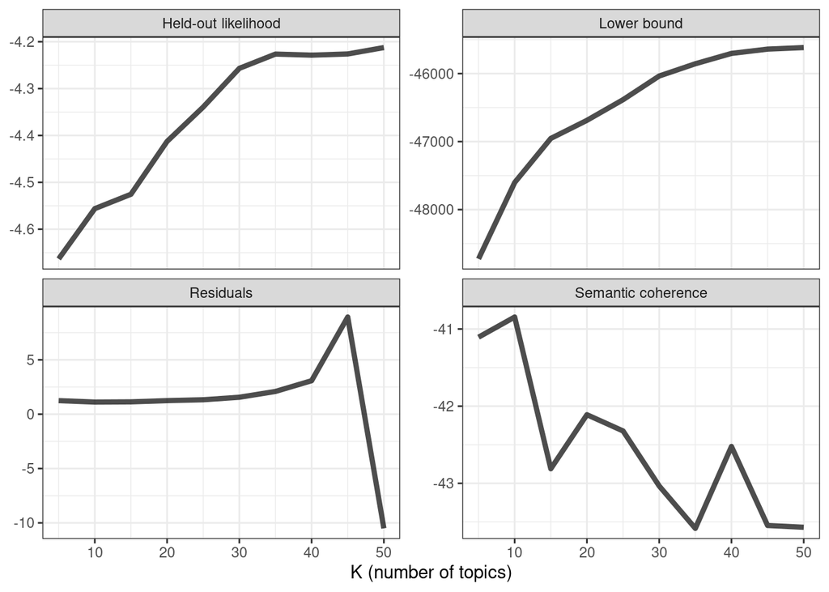

```r
load("many_models")

# calculate diagnostics
heldout <- make.heldout(sparse_docs, seed = 42)

k_result <- many_models %>%
  mutate(exclusivity = map(topic_model, exclusivity),
         semantic_coherence = map(topic_model, semanticCoherence, sparse_docs),
         eval_heldout = map(topic_model, eval.heldout, heldout$missing),
         residual = map(topic_model, checkResiduals, sparse_docs),
         bound =  map_dbl(topic_model, function(x) max(x$convergence$bound)),
         lfact = map_dbl(topic_model, function(x) lfactorial(x$settings$dim$K)),
         lbound = bound + lfact,
         iterations = map_dbl(topic_model, function(x) length(x$convergence$bound)))

# plot diagnostics
k_result %>%
  transmute(K,
            `Lower bound` = lbound,
            Residuals = map_dbl(residual, "dispersion"),
            `Semantic coherence` = map_dbl(semantic_coherence, mean),
            `Held-out likelihood` = map_dbl(eval_heldout, "expected.heldout")) %>%
  gather(Metric, Value, -K) %>%
  ggplot(aes(K, Value)) +
  geom_line(size = 1.5, alpha = 0.7, show.legend = FALSE) +
  facet_wrap(~Metric, scales = "free_y") +
  labs(x = "K (number of topics)",
       y = NULL) +
  theme_bw()
```

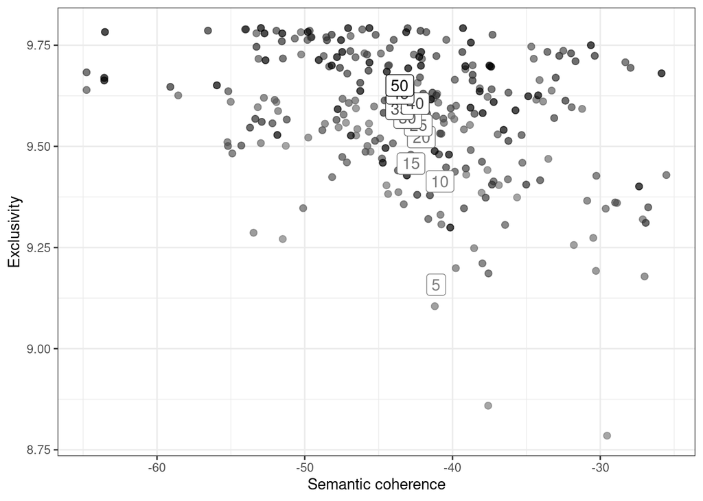

```r
range <- seq(5, 50, 5)

group_means <- k_result %>%
  select(K, exclusivity, semantic_coherence) %>%
  filter(K %in% range) %>%
  unnest(cols = c(exclusivity, semantic_coherence)) %>%
  mutate(K = as.factor(K)) %>%
  group_by(K) %>%
  summarise(
    exclusivity = mean(exclusivity),
    semantic_coherence = mean(semantic_coherence)
  )

# plot semantic coherence and exclusivity
k_result %>%
  select(K, exclusivity, semantic_coherence) %>%
  filter(K %in% range) %>%
  unnest(cols = c(exclusivity, semantic_coherence)) %>%
  mutate(K = as.factor(K)) %>%
  ggplot(aes(semantic_coherence, exclusivity, z = K, color = K)) +
  geom_point(size = 2, alpha = 0.7) +
  geom_label(data = group_means, label = group_means$K, size = 4, show.legend = FALSE) +
  labs(x = "Semantic coherence",
       y = "Exclusivity") +
  theme_bw() +
  theme(legend.position = "none") +
  scale_color_grey(start = .5, end = 0)
```

The diagnostics are somewhat difficult to interpret in this example because we only have a very low number of documents. But it seems like the model with *k* = 30 seems to be a good bet.

```r
# extract K = 30 model
topic_model <- k_result %>%
  filter(K == 30) %>%
  pull(topic_model) %>%
  .[[1]]

topic_model
```

```
A topic model with 30 topics, 84 documents and a 217 word dictionary.
```

Here, we have our topic model. Please check out the materials from class to see how to extract beta and gamma probablities from this model and how to conduct further analyses, such as extracting top words, topics, and plotting.

## (c) Embeddings

**Instruction:** Convert your text data into word embeddings (e.g., by using the `text2vec` package or a Huggingface pipeline).

**Solution:** Let’s create our own word embeddings from the text data using the glove algorithm (here, we use the unprocessed news articles):

```r
tokens <- space_tokenizer(str_to_lower(d$text))

# create vocabulary. Terms will be unigrams (simple words).
it <- itoken(tokens)
vocab <- create_vocabulary(it)

vectorizer <- vocab_vectorizer(vocab)

# use window of 4 for context words (term-co-occurrence matrix)
tcm <- create_tcm(it, vectorizer, skip_grams_window = 4L)

# use 100 dimensions
glove <- GlobalVectors$new(rank = 100, x_max = 10)

# compute
wv_main <- glove$fit_transform(tcm,
                               n_iter = 10,
                               convergence_tol = 0.01,
                               n_threads = 8
                             )
```

```
INFO  [13:20:11.109] epoch 1, loss 0.1739
INFO  [13:20:11.213] epoch 2, loss 0.0827
INFO  [13:20:11.294] epoch 3, loss 0.0577
INFO  [13:20:11.368] epoch 4, loss 0.0448
INFO  [13:20:11.441] epoch 5, loss 0.0367
INFO  [13:20:11.513] epoch 6, loss 0.0309
INFO  [13:20:11.590] epoch 7, loss 0.0265
INFO  [13:20:11.665] epoch 8, loss 0.0230
INFO  [13:20:11.736] epoch 9, loss 0.0201
INFO  [13:20:11.808] epoch 10, loss 0.0177
```

```r
# get results
wv_context <- glove$components
word_vectors <- wv_main + t(wv_context)

word_vectors[1:10, 1:5]
```

```
                      [,1]        [,2]        [,3]        [,4]        [,5]
"ablehnung     -0.19398440 -0.24659068 -0.34558981  0.80359355  0.31773337
"absolut        0.44728252 -0.47664453  0.21434469 -0.11246532 -0.69988412
"afrikanischen -0.05506642  0.25999647  0.14801963  0.73954831  0.03944468
"alte          -0.08445386  0.74159657 -0.43145359 -0.03002937 -0.27433020
"anfang        -0.13902015  0.23762718 -0.40089843  0.05608788  0.48864925
"anlass         0.33573902  0.87522127 -0.08886133  0.38338156  0.19257403
"auch           0.19710886  0.80178022  0.21902028  0.22917440  0.23811002
"barbarisch"   -0.24583858  0.74233934 -0.06060343  0.30828907  0.77330657
"barbarisch".  -0.15783465  0.08475294  0.23320905  0.63704934  0.10055265
"beim          -0.31239795  0.52179764  0.35221398 -0.06387359 -0.23079345
```

Here is a sample of the first 10 words and first 5 dimensions from our embedding space. See the course materials to see how to use this space for further calculations.

We can also use pretrained transformers for our analyses. These can be used to create word embeddings, but also to do classification (e.g., sentiment analysis). In the example below, we will classify emotions within a text.

Tip: you can also run Python code directly within your .Rmd document through the `reticulate` package. This should be all set up in the Docker image. If you are running this locally, either run it directly in python or install all required Python libraries using `reticulate::virtualenv::install()` (check out `reticulate` documentation for details, I set it up for Docker already).

```r
library(reticulate)

Sys.setenv("RETICULATE_PYTHON" = "/home/rstudio/.virtualenvs/dev-environment/bin/python")
Sys.setenv("RETICULATE_PYTHON_ENV" = "/home/rstudio/.virtualenvs/dev-environment")

reticulate::py_config()

# it seems like there is a problem with version of transformers installed in the
# Docker image: https://github.com/huggingface/transformers/issues/20457
# so we install the latest Github Version of transformers and version 2.10 of tensorflow manually
reticulate::virtualenv_remove(".virtualenvs/dev-environment", "tensorflow")
reticulate::virtualenv_remove(".virtualenvs/dev-environment", "transformers")
reticulate::virtualenv_install(".virtualenvs/dev-environment", "tensorflow==2.10")
reticulate::virtualenv_install(".virtualenvs/dev-environment", "git+https://github.com/huggingface/transformers")
```

Unfortunately, this still does not fix the error `No module named 'keras.saving.hdf5_format'`. Hopefully, a future version of the transformers library will fix this.

In theory, however, you would be able to define a function within Python as below and then access it from within `R` using the `py` object.

```python
# here, we define a Python function named classify which we can call from within R below
from transformers import RobertaTokenizerFast, TFRobertaForSequenceClassification, pipeline

# define a function
def classify(texts):
  tokenizer = RobertaTokenizerFast.from_pretrained("arpanghoshal/EmoRoBERTa")
  model = TFRobertaForSequenceClassification.from_pretrained("arpanghoshal/EmoRoBERTa")
  emotion = pipeline('sentiment-analysis', model='arpanghoshal/EmoRoBERTa')
  emotion_labels = emotion(texts)
  return(emotion_labels)
```

Now, we can use the classify function defined above within `R` on some character vetor in our `R` environment.

```r
classification <- py$classify(some_text_vector)
```

# 4 Validating

**Instruction:** Validate your approach according to the methods discussed in class (e.g., by using the `oolong` package).

**Solution:**

## (a) Dictionary

Here, we use the sentiment scores which we calculated from the news articles above. Of course, for our validation, we should use a different sample of text than the one which we use for our analysis. However, for simplicity, we will use the sama data here.

```r
# this code chunk is not evaluated when rendering to speed up rendering
# instead, we save and load the object below

# set seed
set.seed(42)
# Setting up oolong object
gs_test <- create_oolong(input_corpus = d$text,
                         construct = "positive",
                         exact_n = 10)
gs_test

# Conducting gold standrad coding & locking it
gs_test$do_gold_standard_test()
gs_test$lock()

# save
save(gs_test, file = "gs_test")
```

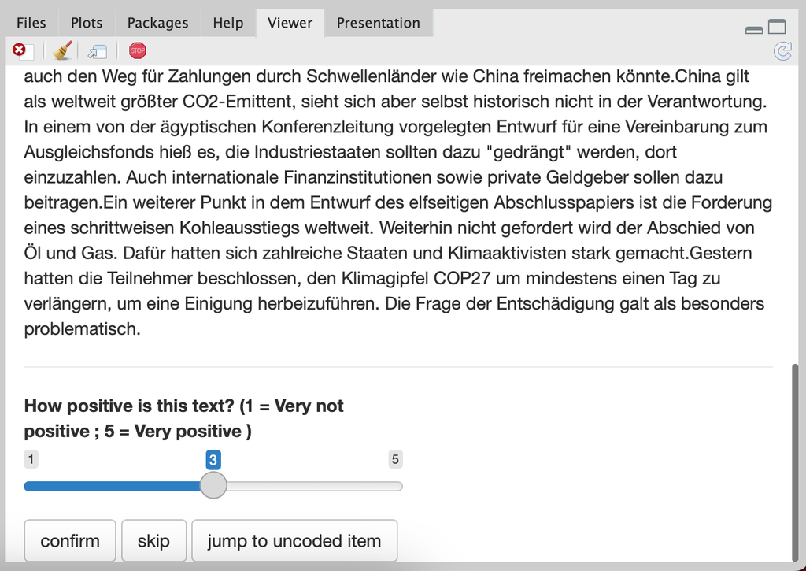

Dictionary Validation Gold Standard Coding

```r
load("gs_test")

# transforming the test data in a quanteda corpus object
gs_corpus <- gs_test$turn_gold()
gs_corpus
```

```
Corpus consisting of 10 documents and 1 docvar.
text1 :
"Die Verlängerung des Klimagipfels hat offenbar in zumindest ..."

text2 :
"Immerhin, eine Neuigkeit hatte sich der Bundeskanzler für se..."

text3 :
"CO2-, Methan- und Stickoxid-Emissionen müssen runter, um dem..."

text4 :
"In der aktuellen Energiekrise bauen die Staaten weltweit in ..."

text5 :
"Neben Staatsvertretern nehmen auch internationale Organisati..."

text6 :
"Die Weltklimakonferenz hat sich erstmals auf einen gemeinsam..."

[ reached max_ndoc ... 4 more documents ]
```

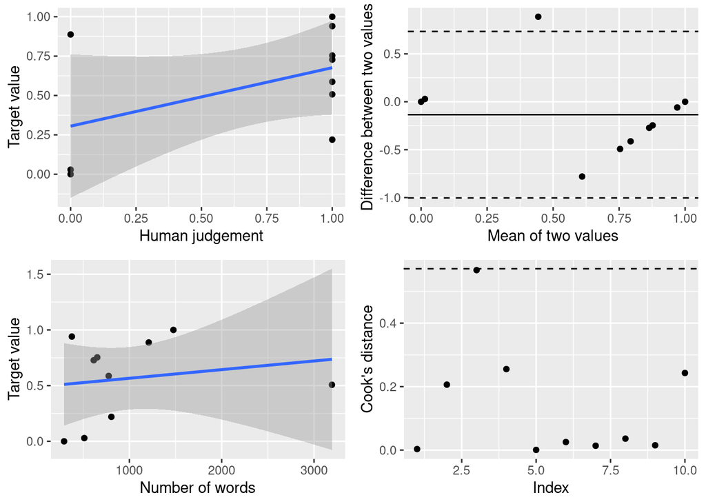

Validation Results

```r
# create character vector of coded texts
gs_texts <-
  gs_corpus %>%
  convert(to = "data.frame") %>%
  pull(text)

# get matching texts from tidy data
gs_data <-
  d %>%
  filter(text %in% gs_texts)

# do dictionary analysis like above
gs_scored <-
  gs_data %>%
  unnest_tokens(word, lemmatized_text, token = "words", to_lower = TRUE) %>%
  anti_join(get_stopwords(language = "de", source="stopwords-iso")) %>%
  filter(!str_detect(word, "NA")) %>% # remove "NA" resulting from lemmatization
  left_join(., sent_dictionary, by = c("word" = "feature")) %>% # join with scores
  mutate(value = if_else(is.na(sentiment), 0, sentiment)) %>% # missing words to 0
  group_by(doc_id) %>%
  summarise(sentiment = mean(value), .groups = "drop") %>%  # average score per text
  left_join(d) # join data back in

# compare with manual coding
results_gs_test <- summarize_oolong(gs_test, target_value = gs_scored$sentiment)

plot(results_gs_test)
```

**Interpretation:**

According to Chan & Sältzer (2020), the plots can be interpreted as follows:

1. Correlation between human judgement and target value - A strong correlation between the two is an indicator of criterion validity of the target value.
2. Bland-Altman plot - If the dots are randomly scattering around the mean value (solid line), it is an indicator of good agreement between human judgement and the target value.
3. Correlation between target value and content length - If there is no strong correlation between the target value and content length, it is an indicator of robustness against the influence of content length (see Chan et al., 2020).
4. Cook’s distance of all data points - if there are only a few dots above the threshold (dotted line), it is an indicator of robustness against the influence of outliers.

## (b) Topic Model

To validate our topic model from above, we use the *k* = 30 topic model and the text data from `d`.

```r
# this code chunk is not evaluated when rendering to speed up rendering
# instead, we save and load the object below

set.seed(42)
# create the oolong object
oolong_topic_model <- create_oolong(input_model = topic_model, input_corpus = d$text, exact_n = 10)

oolong_topic_model

# do word intrusion test
oolong_topic_model$do_word_intrusion_test()

# do topic intrusion test
oolong_topic_model$do_topic_intrusion_test()

# lock the object
oolong_topic_model$lock()

# save
save(oolong_topic_model, file = "oolong_topic_model")
```

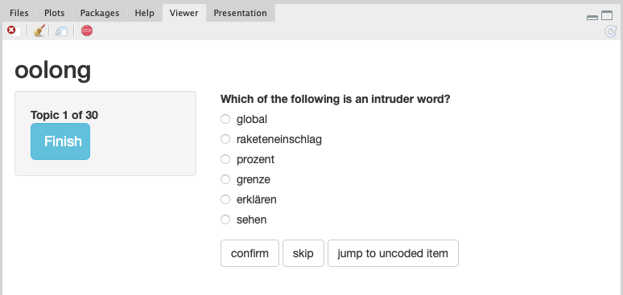

Topic Model Validation Word Intrusion

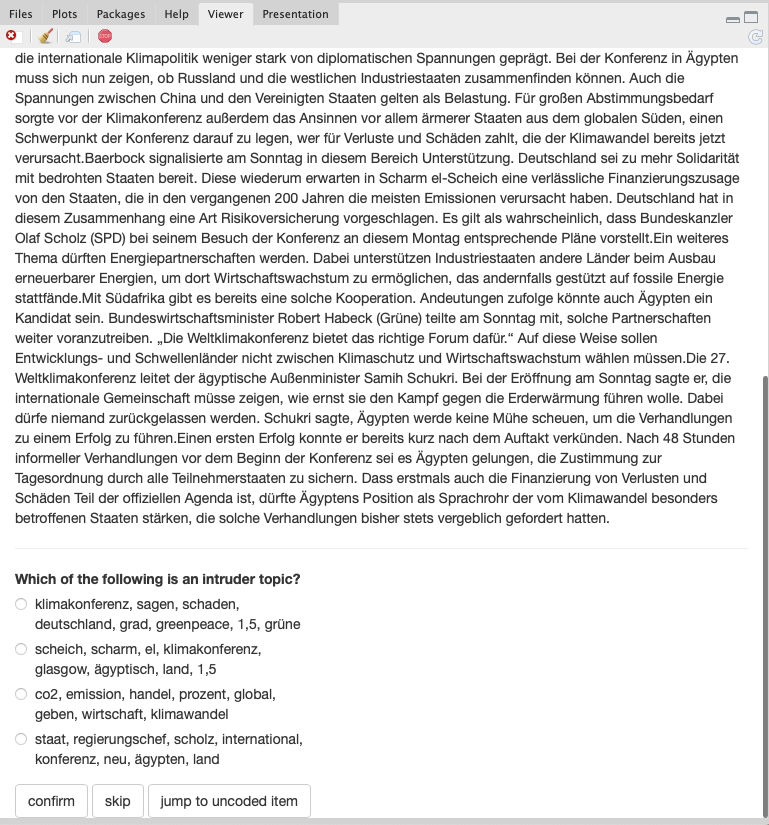

Topic Model Validation Topic Intrusion

```r
load("oolong_topic_model")

oolong_topic_model
```

```
── oolong (topic model) ────────────────────────────────────────────────────────
```

```
✔ WI ✔ TI ✖ WSI
```

```
ℹ WI: k = 30, 30 coded.
```

```
ℹ TI: n = 10, 10 coded.
```

```
── Results: ──
```

```
ℹ 43.33%  precision
```

```
ℹ TLO: -4.162
```

The validation revealed that we likely estimated way too many topics, because it was almost impossible to differentiate them in the topic intrusion test. This is also represented in the poor precision (I guessed for most topics).

# 5 (Optional) Modeling

**Instruction:** Propose one preliminary hypothesis and test it using some statistical model.

**Solution:** Let’s test the hypothesis that Tagesschau will report more positive about the climate conference than FAZ. This is not really based on any theoretical consideration, but should do for a simple demonstration…

H1: The positivity score of news articles vovering COP27 will be more positive for articles from tagesschau than from FAZ.

Because we only compare two sources, a simple t-test will do.

```r
# get summary stats
scored %>%
  # create outlet factor variable
  mutate(outlet = as.factor(pub)) %>%
  # group
  group_by(outlet) %>%
  # get summary stats
  get_summary_stats(sentiment)
```

```
# A tibble: 2 × 14
  outlet   varia…¹     n    min   max median    q1    q3   iqr   mad  mean    sd
  <fct>    <fct>   <dbl>  <dbl> <dbl>  <dbl> <dbl> <dbl> <dbl> <dbl> <dbl> <dbl>
1 FAZ      sentim…    25 -0.2   0.163  0.095 0.047 0.125 0.078 0.064 0.075 0.084
2 Tagessc… sentim…    59 -0.104 0.215  0.077 0.044 0.123 0.079 0.067 0.078 0.064
# … with 2 more variables: se <dbl>, ci <dbl>, and abbreviated variable name
#   ¹variable
```

```r
scored %>%
  # create outlet factor variable
  mutate(outlet = as.factor(pub)) %>%
  # conduct the test
  t_test(sentiment ~ outlet)
```

```
# A tibble: 1 × 8
  .y.       group1 group2        n1    n2 statistic    df     p
* <chr>     <chr>  <chr>      <int> <int>     <dbl> <dbl> <dbl>
1 sentiment FAZ    Tagesschau    25    59    -0.193  36.6 0.848
```

We can see that there is no significant positivity difference (*p* = .848) between news articles that were published in tageschau (*M* = 0.078, *SD* = 0.064) and FAZ (*M* = 0.075, *SD* = 0.084).

## References

Aust, F., & Barth, M. (2022). *papaja: Prepare reproducible APA journal articles with R Markdown*. https://github.com/crsh/papaja

Benoit, K., Watanabe, K., Wang, H., Nulty, P., Obeng, A., Müller, S., & Matsuo, A. (2018). Quanteda: An r package for the quantitative analysis of textual data. *Journal of Open Source Software*, *3*(30), 774. https://doi.org/10.21105/joss.00774

Chan, C., & Sältzer, M. (2020). Oolong: An r package for validating automated content analysis tools. *Journal of Open Source Software*, *5*(55), 2461. https://doi.org/10.21105/joss.02461

Harrison, J. (2022). *RSelenium: R bindings for ’selenium WebDriver’*. https://CRAN.R-project.org/package=RSelenium

Hidayat, A., Csárdi, G., Torok, G., De Marino, I., Gieseke, R., Masala, S., Chang, W., & Weinberg, Z. (2021). *Webdriver: ’WebDriver’ client for ’PhantomJS’*. https://CRAN.R-project.org/package=webdriver

R Core Team. (2022). *R: A language and environment for statistical computing*. R Foundation for Statistical Computing. https://www.R-project.org/

Silge, J., & Robinson, D. (2016). Tidytext: Text mining and analysis using tidy data principles in r. *JOSS*, *1*(3). https://doi.org/10.21105/joss.00037

Wickham, H. (2021). *Rvest: Easily harvest (scrape) web pages*. https://CRAN.R-project.org/package=rvest

Wickham, H., Averick, M., Bryan, J., Chang, W., McGowan, L. D., François, R., Grolemund, G., Hayes, A., Henry, L., Hester, J., Kuhn, M., Pedersen, T. L., Miller, E., Bache, S. M., Müller, K., Ooms, J., Robinson, D., Seidel, D. P., Spinu, V., … Yutani, H. (2019). Welcome to the tidyverse. *Journal of Open Source Software*, *4*(43), 1686. https://doi.org/10.21105/joss.01686

Wijffels, J. (2022). *Udpipe: Tokenization, parts of speech tagging, lemmatization and dependency parsing with the ’UDPipe’ ’NLP’ toolkit*. https://CRAN.R-project.org/package=udpipe